# 5. Incremental Fine-Tuning

1. Setup & Imports
2. MLflow Run Listing
3. Base Model Selection
4. Pre-Retraining Evaluation
5. Error Analysis on New Data
6. Fine-Tuning Configuration
7. Incremental Training
8. MLflow Logging (New Run)
9. Post-Retraining Evaluation
10. Before vs After Comparison

## 1. Setup & Imports

```python
%matplotlib inline
import torch
import mlflow
import numpy as np
import pandas as pd
import matplotlib.pyplot as plt
import cv2
from pathlib import Path
from ultralytics import YOLO

from utils.config import (
    PREPROCESSED_DIR, TEST_DIR, DATASET_1_DIR, DATASET_2_DIR, DATASET_4_DIR,
    CLASS_NAMES, NUM_CLASSES, SEED, RUNS_DIR, ID_TO_NAME, MLFLOW_MODEL_NAME,
)
from utils.mlflow_helpers import (
    setup_mlflow, list_runs, load_model_from_run,
    list_registered_model_versions, load_model_from_registry,
    log_yolo_run_artifacts, log_yolo_epoch_metrics, register_yolo_model,
)
from utils.training_helpers import (
    get_device, create_dataset_yaml,
    evaluate_model, visualize_predictions,
)
```

```python
device = get_device()
```

```
Device : GPU
  GPU  : NVIDIA GeForce MX230
  VRAM : 4.2 GB
```

## 2. MLflow Run Listing

```python
experiment = setup_mlflow()
runs_df = list_runs()

if not runs_df.empty:
    display_cols = ["run_id"]
    if "tags.mlflow.runName" in runs_df.columns:
        display_cols.append("tags.mlflow.runName")
    param_cols = [c for c in runs_df.columns if c.startswith("params.")]
    metric_cols = [c for c in runs_df.columns if c.startswith("metrics.")]
    display_cols += param_cols + metric_cols
    display(runs_df[display_cols])
else:
    print("No runs found. Train a baseline model first (Notebook 3).")
```

```
MLflow tracking URI : http://127.0.0.1:5000
Experiment          : tools_detection
Experiment ID       : 652288683939291895
```

|  | run_id | tags.mlflow.runName | params.img_size | params.epochs | params.source | params.batch_size | params.base_model | params.job_id | params.device | params.learning_rate | ... | metrics.val_dfl_loss | metrics.precision | metrics.mAP50-95 | metrics.train_box_loss | metrics.epoch_precision | metrics.epoch_mAP50 | metrics.train_dfl_loss | metrics.epoch_mAP50_95 | metrics.train_cls_loss | metrics.f1 |
| --- | --- | --- | --- | --- | --- | --- | --- | --- | --- | --- | --- | --- | --- | --- | --- | --- | --- | --- | --- | --- | --- |
| 0 | f85cc08a85a845ca8b06e7b9b5d0141f | api_finetune_job_5 | 640 | 30 | api | 8 | /home/paul/universidad/septimo/IA/final_proyec... | 5 | 0 | 0.0001 | ... | 0.97116 | 0.8424 | 0.8215 | 0.54480 | 0.84376 | 0.92385 | 1.0354 | 0.82373 | 0.58878 | NaN |
| 1 | 1831a6cf214a47b5b16f188957e7e591 | api_finetune_job_4 | 640 | 30 | api | 8 | /home/paul/universidad/septimo/IA/final_proyec... | 4 | 0 | 0.0001 | ... | 0.96754 | 0.8505 | 0.7579 | 0.53961 | 0.93117 | 0.84720 | 1.0265 | 0.75559 | 0.64272 | NaN |
| 2 | ebc630ac3b8f47e3b78ed363e11620e6 | api_finetune_job_2 | 640 | 30 | api | 8 | None | 2 | auto | 0.0001 | ... | 0.96918 | 0.9202 | 0.7608 | 0.55201 | 0.92397 | 0.87463 | 1.0213 | 0.75386 | 0.59132 | NaN |
| 3 | 69a4fb1fb1d64a75916970f3f6a999d1 | api_finetune_job_1 | 640 | 20 | api | 4 | None | 1 | auto | 0.0001 | ... | 1.02560 | 0.9359 | 0.7834 | 0.63635 | 0.93605 | 0.92504 | 1.0925 | 0.78354 | 0.83463 | NaN |
| 4 | 4d068e32429a497ea84ff64fe1c2e3af | finetune_dataset_2_with848e1a7c4c6c405aa95c282... | 640 | 10 | None | 8 | None | None | None | 0.001 | ... | 1.21620 | 0.8550 | 0.6442 | 0.77123 | 0.85498 | 0.84779 | 1.2306 | 0.64484 | 0.76322 | 0.7993 |
| 5 | 848e1a7c4c6c405aa95c2823401d3145 | finetune_dataset_1 | 640 | 50 | None | 8 | None | None | None | 0.001 | ... | 1.18060 | 0.8364 | 0.6538 | 0.65303 | 0.83793 | 0.84499 | 1.1567 | 0.65384 | 0.62811 | 0.8006 |
| 6 | 228014a921414f9d944c114c03dfae3e | bootstrap_transfer_learning | 640 | 25 | None | 8 | None | None | None | 0.01 | ... | 1.57740 | 0.5318 | 0.3187 | 1.05990 | 0.53319 | 0.48567 | 1.4199 | 0.31945 | 1.90870 | 0.4915 |

7 rows × 32 columns

## 3. Base Model Selection

Select the model to fine-tune.

**Option A** — Load the latest (or specific) version from the Model Registry. **Option B** — Paste a `run_id` from the table above.

```python
# ── Option A: Load from Model Registry (recommended) ──
#versions_df = list_registered_model_versions(MLFLOW_MODEL_NAME)
#if not versions_df.empty:
#    display(versions_df)

#BASE_VERSION = None  # None = latest version, or set e.g. "2"
#base_model_path = load_model_from_registry(MLFLOW_MODEL_NAME, version=BASE_VERSION)
#base_model = YOLO(str(base_model_path))
#print(f"Base model loaded: {base_model_path}")
```

```python
# ── Option B: Load by run_id ──
BASE_RUN_ID = "f85cc08a85a845ca8b06e7b9b5d0141f"  # <-- paste run_id here
base_model_path = load_model_from_run(BASE_RUN_ID)
base_model = YOLO(str(base_model_path))
print(f"Base model loaded: {base_model_path}")
```

```
Model downloaded: /home/paul/universidad/septimo/IA/final_proyect/notebooks/mlruns/652288683939291895/f85cc08a85a845ca8b06e7b9b5d0141f/artifacts/model/best.pt
Base model loaded: /home/paul/universidad/septimo/IA/final_proyect/notebooks/mlruns/652288683939291895/f85cc08a85a845ca8b06e7b9b5d0141f/artifacts/model/best.pt
```

## 4. Pre-Retraining Evaluation

Evaluate the base model on the **fixed test set** before any retraining.

```python
pre_metrics = evaluate_model(base_model)

print("── Base Model Metrics (test set) ──")
for k, v in pre_metrics.items():
    print(f"  {k:12s}: {v:.4f}")
```

```
Ultralytics YOLOv8.0.196 🚀 Python-3.10.14 torch-1.13.1+cu117 CUDA:0 (NVIDIA GeForce MX230, 4034MiB)
Model summary (fused): 168 layers, 3006428 parameters, 0 gradients, 8.1 GFLOPs
val: Scanning /home/paul/universidad/septimo/IA/final_proyect/notebooks/data/pre_process_2/test/labels.
val: WARNING ⚠️ /home/paul/universidad/septimo/IA/final_proyect/notebooks/data/pre_process_2/test/images/000310_jpg.rf.9c268e6426525562046d07ac077754df.jpg: 1 duplicate labels removed
val: New cache created: /home/paul/universidad/septimo/IA/final_proyect/notebooks/data/pre_process_2/test/labels.cache
                 Class     Images  Instances      Box(P          R      mAP50  mAP50-95): 100%|████████
                   all        388        667      0.609      0.741      0.758      0.646
Speed: 1.0ms preprocess, 21.9ms inference, 0.0ms loss, 0.6ms postprocess per image
Results saved to /home/paul/.pyenv/runs/detect/val20
```

```
── Base Model Metrics (test set) ──
  mAP50       : 0.7581
  mAP50-95    : 0.6461
  precision   : 0.6092
  recall      : 0.7411
  f1          : 0.6687
```

## 5. Error Analysis on New Data

Predict on the **new training dataset** to identify incorrect or low-confidence predictions before retraining.

```python
# ── Select the new training dataset ──
NEW_DATASET = "dataset_4"

new_data_dir = PREPROCESSED_DIR / "train" / NEW_DATASET
new_images = new_data_dir / "images"
new_labels = new_data_dir / "labels"

img_count = len(list(new_images.glob("*.jpg")))
print(f"New dataset   : {NEW_DATASET}")
print(f"Images        : {img_count}")
```

```
New dataset   : dataset_4
Images        : 990
```

```python
# Predict on new data and find low-confidence / missed detections
image_files = sorted(new_images.glob("*.jpg"))
low_conf_images = []

for img_path in image_files:
    results = base_model.predict(str(img_path), imgsz=640, conf=0.25, verbose=False)
    boxes = results[0].boxes

    # Read ground-truth label count
    lbl_path = new_labels / f"{img_path.stem}.txt"
    gt_count = 0
    if lbl_path.exists():
        with open(lbl_path) as f:
            gt_count = sum(1 for line in f if line.strip())

    pred_count = len(boxes) if boxes is not None else 0
    avg_conf = float(boxes.conf.mean()) if boxes is not None and len(boxes) > 0 else 0.0

    if pred_count < gt_count or avg_conf < 0.5:
        low_conf_images.append({
            "image": img_path.name,
            "gt_objects": gt_count,
            "predicted": pred_count,
            "avg_confidence": round(avg_conf, 3),
        })

print(f"Images with low confidence or missed detections: {len(low_conf_images)} / {len(image_files)}")
if low_conf_images:
    display(pd.DataFrame(low_conf_images).head(15))
```

```
Images with low confidence or missed detections: 228 / 990
```

|  | image | gt_objects | predicted | avg_confidence |
| --- | --- | --- | --- | --- |
| 0 | 000019_jpg.rf.5fc911111fe5efa2b734e02dfec62ac0... | 4 | 2 | 0.643 |
| 1 | 000031_jpg.rf.84e55569386833e0a643cb1f7b969f0b... | 1 | 2 | 0.438 |
| 2 | 000032_jpg.rf.c24875150d3bd2a9168fdd27be902174... | 9 | 7 | 0.504 |
| 3 | 000040_jpg.rf.892704f77ba93e1e50b0bf2f0f7cc6eb... | 2 | 1 | 0.828 |
| 4 | 000043_jpg.rf.6d8a03d4ffa3eaca9600a7d6516d3d63... | 3 | 3 | 0.370 |
| 5 | 000043_jpg.rf.de0fad6f44097b7e429c32afa2b3005d... | 3 | 4 | 0.475 |
| 6 | 000045_jpg.rf.3acaece58f0467d6a2c9fef80693dc7a... | 1 | 1 | 0.348 |
| 7 | 000045_jpg.rf.a5313bec833d94030c9b2d9c854de44c... | 1 | 2 | 0.486 |
| 8 | 000140_jpg.rf.9e2f874ebf0fe23a964f06ba3d9c211b... | 1 | 2 | 0.476 |
| 9 | 000152_jpg.rf.a3029c042de2e3675402ea6c940f508b... | 7 | 4 | 0.578 |
| 10 | 000166_jpg.rf.4edccbedb6de7d471332d7fa949bcf62... | 4 | 2 | 0.931 |
| 11 | 000175_jpg.rf.38cec8ec1c1a047ae0a30bed9155dc50... | 3 | 1 | 0.414 |
| 12 | 000175_jpg.rf.f46d58aeaa0a1dc01b124e6cd4adaffd... | 3 | 1 | 0.786 |
| 13 | 000182_jpg.rf.1de0f1d3773d7882b17c5446e0647147... | 2 | 1 | 0.819 |
| 14 | 000182_jpg.rf.5055a13ad2af70b7e26f7488389ad900... | 2 | 1 | 0.848 |

[figure not shown]

```python
# Visualize some error samples
if low_conf_images:
    error_names = [e["image"] for e in low_conf_images[:6]]
    cols = min(3, len(error_names))
    rows = (len(error_names) + cols - 1) // cols
    fig, axes = plt.subplots(rows, cols, figsize=(6 * cols, 5 * rows))
    axes = np.array(axes).flatten() if rows * cols > 1 else np.array([axes])

    for idx, name in enumerate(error_names):
        img_path = new_images / name
        res = base_model.predict(str(img_path), imgsz=640, conf=0.25, verbose=False)
        annotated = res[0].plot()
        axes[idx].imshow(cv2.cvtColor(annotated, cv2.COLOR_BGR2RGB))
        axes[idx].set_title(name, fontsize=9)
        axes[idx].axis("off")

    for idx in range(len(error_names), len(axes)):
        axes[idx].axis("off")
    plt.suptitle("Error samples — base model on new data", fontsize=13)
    plt.tight_layout()
    plt.show()
else:
    print("No significant errors found.")
```

## 6. Fine-Tuning Configuration

```python
# ── Configurable hyperparameters ──
FT_EPOCHS     = 30
FT_BATCH_SIZE = 8
FT_LR         = 0.001
FT_IMG_SIZE   = 640

print(f"Dataset       : {NEW_DATASET}")
print(f"Epochs        : {FT_EPOCHS}")
print(f"Batch size    : {FT_BATCH_SIZE}")
print(f"Learning rate : {FT_LR}")
print(f"Image size    : {FT_IMG_SIZE}")
```

```
Dataset       : dataset_4
Epochs        : 30
Batch size    : 8
Learning rate : 0.001
Image size    : 640
```

## 7. Incremental Training

Fine-tune the base model on the new training dataset.

```python
# Create YAML for the new dataset
ft_yaml = create_dataset_yaml(NEW_DATASET)

# Load a fresh copy of the base model for training
ft_model = YOLO(str(base_model_path))

ft_results = ft_model.train(
    data=str(ft_yaml),
    epochs=FT_EPOCHS,
    batch=FT_BATCH_SIZE,
    imgsz=FT_IMG_SIZE,
    lr0=FT_LR,
    device=device,
    seed=SEED,
    project=str(RUNS_DIR),
    name=f"{NEW_DATASET}_finetune",
    exist_ok=True,
    verbose=True,
)

ft_best_pt = Path(ft_model.trainer.save_dir) / "weights" / "best.pt"
print(f"\nFine-tuned model: {ft_best_pt}")
```

```
YAML created: /home/paul/universidad/septimo/IA/final_proyect/notebooks/data/pre_process_2/dataset_4_data.yaml
```

[output not shown]

[output cut: 159 more lines]

```
30 epochs completed in 0.973 hours.
Optimizer stripped from /home/paul/universidad/septimo/IA/final_proyect/notebooks/runs/dataset_4_finetune/weights/last.pt, 6.2MB
Optimizer stripped from /home/paul/universidad/septimo/IA/final_proyect/notebooks/runs/dataset_4_finetune/weights/best.pt, 6.2MB

Validating /home/paul/universidad/septimo/IA/final_proyect/notebooks/runs/dataset_4_finetune/weights/best.pt...
Ultralytics YOLOv8.0.196 🚀 Python-3.10.14 torch-1.13.1+cu117 CUDA:0 (NVIDIA GeForce MX230, 4034MiB)
Model summary (fused): 168 layers, 3006428 parameters, 0 gradients, 8.1 GFLOPs
                 Class     Images  Instances      Box(P          R      mAP50  mAP50-95): 100%|████████
                   all        388        667      0.792      0.705      0.736      0.644
                Hammer        388        297      0.813      0.775      0.804      0.709
                Pliers        388          4      0.544       0.75      0.524      0.463
           Screwdriver        388        229      0.938      0.461      0.735      0.592
                Wrench        388        137      0.873      0.832      0.881      0.813
Speed: 1.0ms preprocess, 29.2ms inference, 0.0ms loss, 0.5ms postprocess per image
Results saved to /home/paul/universidad/septimo/IA/final_proyect/notebooks/runs/dataset_4_finetune
```

```
Fine-tuned model: /home/paul/universidad/septimo/IA/final_proyect/notebooks/runs/dataset_4_finetune/weights/best.pt
```

## 8. MLflow Logging

Log this fine-tuning run as a **new** MLflow run. Previous runs are never modified or overwritten.

```python
# Evaluate fine-tuned model on test set
ft_model_eval = YOLO(str(ft_best_pt))
metrics = evaluate_model(ft_model_eval, data_yaml=ft_yaml, img_size=FT_IMG_SIZE)

# Re-establish MLflow connection (falls back to file store if server is down)
setup_mlflow()

with mlflow.start_run(run_name=f"finetune_{NEW_DATASET}") as run:
    # Hyperparameters
    mlflow.log_params({
        "base_model_run_id": BASE_RUN_ID,
        "dataset": NEW_DATASET,
        "epochs": FT_EPOCHS,
        "batch_size": FT_BATCH_SIZE,
        "img_size": FT_IMG_SIZE,
        "learning_rate": FT_LR,
        "seed": SEED,
    })

    mlflow.log_metrics(metrics)

    # Model artifact (.pt copy)
    mlflow.log_artifact(str(ft_best_pt), artifact_path="model")

    # YOLO training artifacts (curves, confusion matrices, results)
    ft_save_dir = Path(ft_model.trainer.save_dir)
    log_yolo_run_artifacts(ft_save_dir)

    # Per-epoch training metrics from results.csv
    log_yolo_epoch_metrics(ft_save_dir)

    # Register model in MLflow Model Registry
    register_yolo_model(ft_best_pt, MLFLOW_MODEL_NAME)

    ft_run_id = run.info.run_id

print(f"\nMLflow Run ID : {ft_run_id}")
print(f"Run Name      : finetune_{NEW_DATASET}")
```

```
Ultralytics YOLOv8.0.196 🚀 Python-3.10.14 torch-1.13.1+cu117 CUDA:0 (NVIDIA GeForce MX230, 4034MiB)
Model summary (fused): 168 layers, 3006428 parameters, 0 gradients, 8.1 GFLOPs
val: Scanning /home/paul/universidad/septimo/IA/final_proyect/notebooks/data/pre_process_2/test/labels.
val: WARNING ⚠️ /home/paul/universidad/septimo/IA/final_proyect/notebooks/data/pre_process_2/test/images/000310_jpg.rf.9c268e6426525562046d07ac077754df.jpg: 1 duplicate labels removed
                 Class     Images  Instances      Box(P          R      mAP50  mAP50-95): 100%|████████
                   all        388        667      0.792      0.705      0.735      0.644
Speed: 1.1ms preprocess, 33.9ms inference, 0.0ms loss, 3.4ms postprocess per image
Results saved to /home/paul/.pyenv/runs/detect/val23
```

```
MLflow tracking URI : http://127.0.0.1:5000
Experiment          : tools_detection
Experiment ID       : 652288683939291895
  Logged 23 YOLO artifacts from dataset_4_finetune/
  Logged 30 epochs of training metrics
```

```
Registered model 'tools_detection_yolo' already exists. Creating a new version of this model...
2026/02/04 08:29:28 INFO mlflow.store.model_registry.abstract_store: Waiting up to 300 seconds for model version to finish creation. Model name: tools_detection_yolo, version 12
```

```
  Model registered in: tools_detection_yolo

MLflow Run ID : e088cd76dda14babbdd1fcf49b12dcc5
Run Name      : finetune_dataset_4
```

```
Created version '12' of model 'tools_detection_yolo'.
```

## 9. Post-Retraining Evaluation

Evaluate the fine-tuned model on the **same fixed test set**.

```python
print("── Post-Retraining Metrics (test set) ──")
for k, v in metrics.items():
    print(f"  {k:12s}: {v:.4f}")
```

```
── Post-Retraining Metrics (test set) ──
  mAP50       : 0.7352
  mAP50-95    : 0.6436
  precision   : 0.7924
  recall      : 0.7045
  f1          : 0.7459
```

[figure not shown]

```python
visualize_predictions(ft_model_eval, TEST_DIR / "images", num_images=18, conf=0.5)
```

## 10. Before vs After Comparison

Side-by-side comparison of metrics before and after fine-tuning on the same fixed test set.

|  | Metric | Before | After | Delta | Improved |
| --- | --- | --- | --- | --- | --- |
| 0 | mAP50 | 0.7581 | 0.7352 | -0.0229 | No |
| 1 | mAP50-95 | 0.6461 | 0.6436 | -0.0025 | No |
| 2 | precision | 0.6092 | 0.7924 | 0.1832 | Yes |
| 3 | recall | 0.7411 | 0.7045 | -0.0366 | No |
| 4 | f1 | 0.6687 | 0.7459 | 0.0772 | Yes |

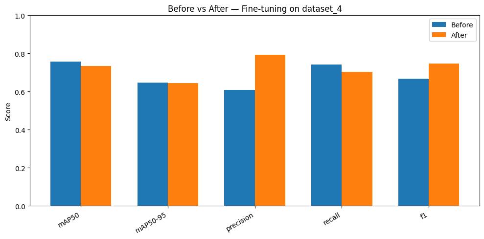

```python
comparison = pd.DataFrame({
    "Metric": list(pre_metrics.keys()),
    "Before": list(pre_metrics.values()),
    "After": list(metrics.values()),
})
comparison["Delta"] = comparison["After"] - comparison["Before"]
comparison["Improved"] = comparison["Delta"].apply(lambda d: "Yes" if d > 0 else ("No" if d < 0 else "-"))

display(comparison)

# Bar chart
x = np.arange(len(comparison))
width = 0.35
fig, ax = plt.subplots(figsize=(10, 5))
ax.bar(x - width / 2, comparison["Before"], width, label="Before")
ax.bar(x + width / 2, comparison["After"], width, label="After")
ax.set_xticks(x)
ax.set_xticklabels(comparison["Metric"], rotation=30, ha="right")
ax.set_ylabel("Score")
ax.set_title(f"Before vs After — Fine-tuning on {NEW_DATASET}")
ax.legend()
ax.set_ylim(0, 1)
plt.tight_layout()
plt.show()
```